# Decision_Tree2_Erin_Kennedy

A00275664

2024-04-04

# Decision Trees for Obesity Rate Prediction

## Introduction

### Preparation

```r
#Install Relevant Packages
library(tidyverse)
library(caret)
library(rpart)
library(dplyr)
library(gmodels)
```

Import the **obesity** dataset and install relevant packages using the **read.csv()** command

```r
#Import the obesity dataset and examine the structure
obesity<-read.csv("~/A00275664/Data/ObesityDataSet_raw_and_data_sinthetic.csv", header = T, sep = ",",
                  stringsAsFactors = FALSE)
str(obesity)
```

```
## 'data.frame':    2111 obs. of  17 variables:
##  $ Gender                        : chr  "Female" "Female" "Male" "Male" ...
##  $ Age                           : num  21 21 23 27 22 29 23 22 24 22 ...
##  $ Height                        : num  1.62 1.52 1.8 1.8 1.78 1.62 1.5 1.64 1.78 1.72 ...
##  $ Weight                        : num  64 56 77 87 89.8 53 55 53 64 68 ...
##  $ family_history_with_overweight: chr  "yes" "yes" "yes" "no" ...
##  $ FAVC                          : chr  "no" "no" "no" "no" ...
##  $ FCVC                          : num  2 3 2 3 2 2 3 2 3 2 ...
##  $ NCP                           : num  3 3 3 3 1 3 3 3 3 3 ...
##  $ CAEC                          : chr  "Sometimes" "Sometimes" "Sometimes" "Sometimes" ...
##  $ SMOKE                         : chr  "no" "yes" "no" "no" ...
##  $ CH2O                          : num  2 3 2 2 2 2 2 2 2 2 ...
##  $ SCC                           : chr  "no" "yes" "no" "no" ...
##  $ FAF                           : num  0 3 2 2 0 0 1 3 1 1 ...
##  $ TUE                           : num  1 0 1 0 0 0 0 0 1 1 ...
##  $ CALC                          : chr  "no" "Sometimes" "Frequently" "Frequently" ...
##  $ MTRANS                        : chr  "Public_Transportation" "Public_Transportation" "Public_Transportation" "Walking" ...
##  $ NObeyesdad                    : chr  "Normal_Weight" "Normal_Weight" "Normal_Weight" "Overweight_Level_I" ...
```

```r
#Rename unclear column headings for better understanding
obesity <- obesity %>%
  rename("obesity_level" = "NObeyesdad",
         "high_cal_foods" = "FAVC",
         "veg_meals" = "FCVC",
         "eat_between_meals" = "CAEC",
         "main_meals_count" = "NCP",
         "family_history" = "family_history_with_overweight")


obesity <- obesity %>%
  mutate(obesity_level = recode(obesity_level,
                                "Normal_Weight" = "NW",
                                "Overweight_Level_I" = "OWI",
                                "Overweight_Level_II" = "OWII",
                                "Obesity_Type_I" = "OTI",
                                "Insufficient_Weight" = "IW",
                                "Obesity_Type_II" = "OTII",
                                "Obesity_Type_III" = "OTIII"))
```

### Important Tables

Important variables, such as *Gender* aree viewed in table form to understand their distribution clearly. *Obesity_level* is the classifying variable. There is a slight class imbalance between the levels. A class imbalance can result in problems such as a negative effect on the accuracy and performance of the model. There are more entries of **Obesity_Type_I** than other data values, which can ‘bias’ the model or enable better prediction for **Obesity_Type_I** data rather than the rest of the data values.

```r
# Familiarise with columns that may be important
unique(obesity$MTRANS)
unique(obesity$eat_between_meals)
unique(obesity$CALC)
#View tables that may be important
table(obesity$obesity_level)
table (obesity$Gender)
table(obesity$high_cal_foods)
table(obesity$eat_between_meals)
```

[output not shown]

Null values and other obscure data values, such as **?** are scrutinised for in the dataset. These values can interfer with the model and alter predictions with their presence. However, there are none of these values present in this dataset.

```r
# Check for missing values in obesity dataset
missing_values <- colSums(is.na(obesity))
print(missing_values)
```

[output not shown]

Change CALC to a factor to allow easier prediction further along

```r
# Change CALC structure to a factor to avoid future errors
obesity$CALC <- factor(obesity$CALC, levels = c("no", "Sometimes", "Frequently", "Always"))
```

```r
# Check the structure of the dataframe after processing
str(obesity)
```

# Model Creation

### Creating Random Training and Test Datasets

Here, the **caret** package is utilised. The *obesity_level* variable is partitioned to create a training sample dataset, containing 80% of the **obesity** data. The remaining 20% will be used to test the model and evaluate its accuracy rate.

```r
# Split the data into training and testing sets
set.seed(123)
training.samples <- obesity$obesity_level %>% createDataPartition(p = 0.8, list = FALSE)
obesity_train <- obesity[training.samples, ]
obesity_test <- obesity[-training.samples, ]
```

It can be calculated from the tables that the training and test sets both have an average distribution of values resting at **14.28%**, however, both remain skewed in favour of **Obesity_Level_I** which may still allow for inaccuracy with regards to bias due to the fact that the model has less data to learn and train from regarding the other data values.

```r
#Creating Random training and test datasets
set.seed(123)
training.samples <- obesity$obesity_level %>%
  createDataPartition(p = 0.8, list = FALSE)

obesity_train <- obesity[training.samples, ]
obesity_test <- obesity[-training.samples, ]
# Both sets have an approximately equal distribution in correspondance with eachother
prop.table(table(obesity_train$obesity_level))
```

```
##
##        IW        NW       OTI      OTII     OTIII       OWI      OWII
## 0.1289178 0.1360142 0.1661739 0.1407451 0.1537552 0.1371969 0.1371969
```

```r
prop.table(table(obesity_test$obesity_level))
```

```
##
##        IW        NW       OTI      OTII     OTIII       OWI      OWII
## 0.1285714 0.1357143 0.1666667 0.1404762 0.1523810 0.1380952 0.1380952
```

### Model Plotting

Here, the decision tree model **obesity_model** is created. The initial plot points and lines are constructed and labeled with the relevant variables and attributes.

```r
set.seed(345)
obesity_model <- rpart(obesity_level ~., data = obesity_train, method = "class")
```

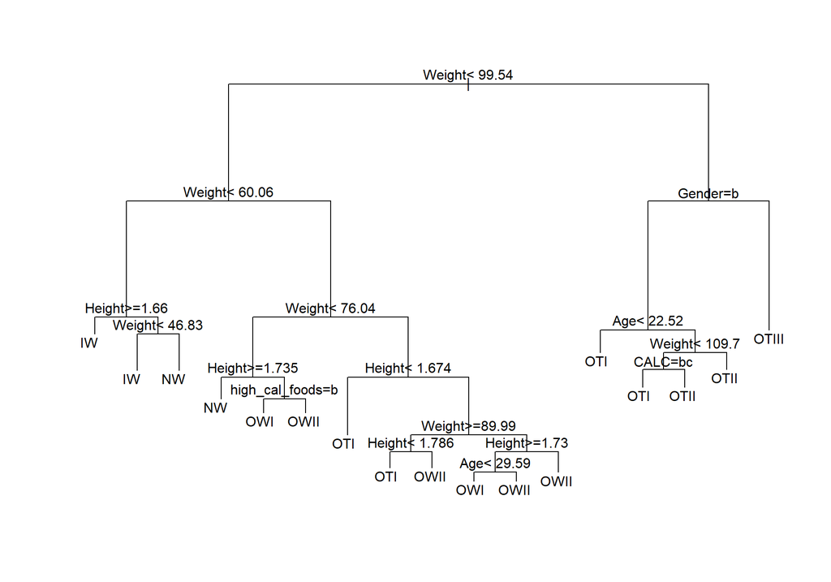

```r
# Plot the trees
par(xpd = NA) # Avoid clipping the text in some device
plot(obesity_model)
text(obesity_model, digits = 5)
```

# Predictions

### Test Data Predictions

Now the model is trained, predictions are made using *dplyr*. Predictions are made based upon the decision tree *obesity_model* and stored in *predicted.classes*. Next the accuracy rate will be calculated.

```r
# Make predictions on the test data
predicted.classes <- obesity_model %>%
  predict(obesity_test, type = "class")
head(predicted.classes)
```

```
##    1    5   11   18   21   24
## OWII  OWI  OTI  OTI  OTI  OTI
## Levels: IW NW OTI OTII OTIII OWI OWII
```

The model accuracy is high with 84%. This indicates the model is performing well predicting the obesity level of a subject. This can be interpreted further with a confusion matrix, which can be seen later. First the decision tree will need to be pruned to prevent overfitting.

```r
#Model accuracy with test data
mean(predicted.classes == obesity_test$obesity_level) #[1] 0.8404762
```

```
## [1] 0.8404762
```

# Pruning

### The Complexity Parameter

From the complexity parameter (CP) information below, it can be seen from the *xerror* rate that the error rate does not increase after each split. It decreases significantly. Pruning in this circumstance would not have any benefits on the accuracy rate. This may be due to overfitting.

```r
# Pruning
printcp(obesity_model)
```

```
##
## Classification tree:
## rpart(formula = obesity_level ~ ., data = obesity_train, method = "class")
##
## Variables actually used in tree construction:
## [1] Age            CALC           Gender         Height         high_cal_foods
## [6] Weight
##
## Root node error: 1410/1691 = 0.83383
##
## n= 1691
##
##          CP nsplit rel error  xerror     xstd
## 1  0.157092      0   1.00000 1.00000 0.010856
## 2  0.148227      2   0.68582 0.69787 0.014385
## 3  0.076596      3   0.53759 0.55603 0.014544
## 4  0.073759      4   0.46099 0.52411 0.014466
## 5  0.032624      5   0.38723 0.39220 0.013682
## 6  0.029078      7   0.32199 0.33617 0.013099
## 7  0.027660      8   0.29291 0.31773 0.012870
## 8  0.022340      9   0.26525 0.31064 0.012777
## 9  0.020567     11   0.22057 0.26667 0.012127
## 10 0.017730     12   0.20000 0.23262 0.011532
## 11 0.011348     13   0.18227 0.19929 0.010856
## 12 0.010000     16   0.14823 0.18227 0.010470
```

However if the **obesity_model** did need to be pruned, the lowest *xerror* rate would need to be identified and its corresponding *cp* rate. For example the code below shows how this would be performed.

However in this particular circumstance there would be no change to the accuracy rate as the *xerror* rate is also the last cp value. Although pruning by the 11th node can help create a simpler, more understandable decision tree, despite a less accurate tree.

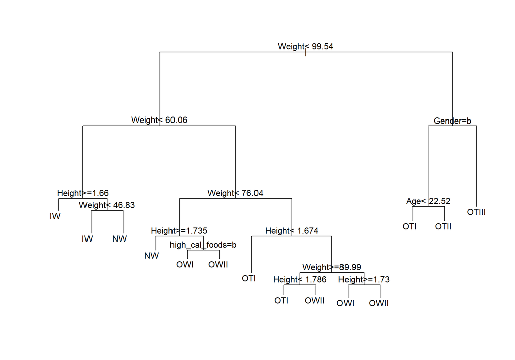

```r
obesity_model2 <- prune(obesity_model, cp= 0.011348)
# Plot the tree
par(xpd = NA)
plot(obesity_model2)
text(obesity_model2, digits = .5)
```

### Pruned Model Predictions

A new accuracy rate is calculated with the pruned model **obesity_model2**. Pruning can help to increase the accuracy rate of models by removing various leaf nodes which do not add to the accuracy of the model. Calculating a new accuracy rate after pruning can create a clearer, simpler and generally a more accurate decision tree model. Pruning by the 11th node can help create a simpler, more understandable decision tree, despite a less accurate tree.

```r
#Make predictions on the test data with pruned model
predicted.classes <- obesity_model2 %>%
  predict(obesity_test, type = "class")
# Compute model accuracy rate on test data
mean(predicted.classes == obesity_test$obesity_level) # [1] 0.8309524 Reduction of 1% in accuracy
```

```
## [1] 0.8309524
```

```r
summary(obesity_model2)
```

[output not shown]

## ‘Caret’ Pruning

The **caret** package contains functions that choose the most appropriate complexity parameter (cp) to prune the decision tree with the aim of increasing prediction accuracy rate and creating a simpler tree. Here *obesity_model3* is created to evaluate which cp is ideal for a simplified, clearer decision tree.

```r
# new model fit onto the training set
set.seed(345)
obesity_model3 <- train(
  obesity_level ~., data = obesity_train, method = "rpart",
  trControl = trainControl("cv", number = 10),
  tuneLength = 12) # number of cp values to evaluate
```

The new model’s accuracy rate is then plotted with different cp values to be evaluated with.

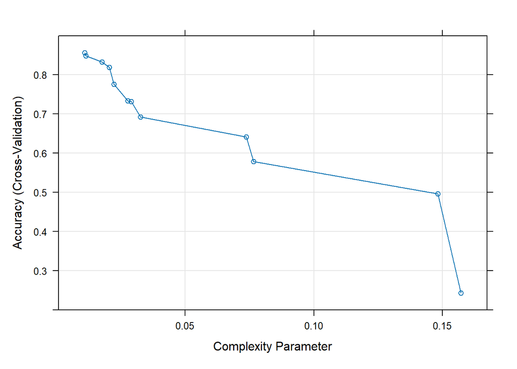

```r
#Plot obesity_model3 accuracy with different cp values
plot(obesity_model3)
```

It can be seen from the plot that the data value(cp) with the highest accuracy rate appears to fall along the .8 to .9% accuracy rate and between .01 and .02 cp value. This cp can be specified with bestTune in **caret**.

```r
# Use bestTune to find the most best cp for model accuracy
obesity_model3$bestTune # cp 0.01099291
```

```
##           cp
## 1 0.01099291
```

The most accurate complexity parameter is found to be .011.

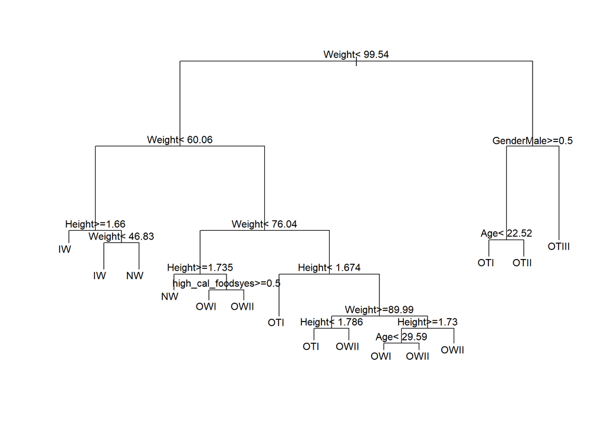

```r
# Plot the final tree model
par(xpd = NA)
plot(obesity_model3$finalModel)
text(obesity_model3$finalModel, digits = 3)
```

```r
# Decision rules in the model
obesity_model3$finalModel
```

```
## n= 1691
##
## node), split, n, loss, yval, (yprob)
##       * denotes terminal node
##
##   1) root 1691 1410 OTI (0.13 0.14 0.17 0.14 0.15 0.14 0.14)
##     2) Weight< 99.53555 1107  875 OWI (0.2 0.21 0.18 0.0036 0 0.21 0.21)
##       4) Weight< 60.059 344  130 IW (0.62 0.35 0 0 0 0.026 0.0029)
##         8) Height>=1.660223 153   16 IW (0.9 0.1 0 0 0 0 0) *
##         9) Height< 1.660223 191   87 NW (0.4 0.54 0 0 0 0.047 0.0052)
##          18) Weight< 46.82781 81    8 IW (0.9 0.099 0 0 0 0 0) *
##          19) Weight>=46.82781 110   14 NW (0.036 0.87 0 0 0 0.082 0.0091) *
##       5) Weight>=60.059 763  536 OWII (0.0052 0.14 0.26 0.0052 0 0.29 0.3)
##        10) Weight< 76.04126 280  138 OWI (0.014 0.34 0.0071 0 0 0.51 0.14)
##          20) Height>=1.735189 47    6 NW (0.085 0.87 0 0 0 0.043 0) *
##          21) Height< 1.735189 233   93 OWI (0 0.23 0.0086 0 0 0.6 0.16)
##            42) high_cal_foodsyes>=0.5 173   45 OWI (0 0.24 0.012 0 0 0.74 0.0058) *
##            43) high_cal_foodsyes< 0.5 60   23 OWII (0 0.18 0 0 0 0.2 0.62) *
##        11) Weight>=76.04126 483  290 OTI (0 0.033 0.4 0.0083 0 0.17 0.39)
##          22) Height< 1.674047 164   30 OTI (0 0 0.82 0.024 0 0 0.16) *
##          23) Height>=1.674047 319  156 OWII (0 0.05 0.18 0 0 0.25 0.51)
##            46) Weight>=89.98668 91   33 OTI (0 0 0.64 0 0 0.011 0.35)
##              92) Height< 1.786123 57    1 OTI (0 0 0.98 0 0 0 0.018) *
##              93) Height>=1.786123 34    3 OWII (0 0 0.059 0 0 0.029 0.91) *
##            47) Weight< 89.98668 228   97 OWII (0 0.07 0.0044 0 0 0.35 0.57)
##              94) Height>=1.729588 137   58 OWI (0 0.12 0 0 0 0.58 0.31)
##               188) Age< 29.58825 116   39 OWI (0 0.13 0 0 0 0.66 0.21) *
##               189) Age>=29.58825 21    3 OWII (0 0.048 0 0 0 0.095 0.86) *
##              95) Height< 1.729588 91    2 OWII (0 0 0.011 0 0 0.011 0.98) *
##     3) Weight>=99.53555 584  324 OTIII (0 0 0.15 0.4 0.45 0 0.0068)
##       6) GenderMale>=0.5 324   91 OTII (0 0 0.27 0.72 0.0031 0 0.012)
##        12) Age< 22.52469 64   12 OTI (0 0 0.81 0.17 0.016 0 0) *
##        13) Age>=22.52469 260   38 OTII (0 0 0.13 0.85 0 0 0.015) *
##       7) GenderMale< 0.5 260    1 OTIII (0 0 0 0.0038 1 0 0) *
```

From the information above, multiple leaf nodes can be seen. Weight, gender and height appear to be the primary general decision-makers of the tree.

```r
# Make predictions on the test data
obesity_predictions <- obesity_model3 %>% predict(obesity_test)
# Compute model accuracy rate on test data
mean(obesity_predictions == obesity_test$obesity_level)
```

```
## [1] 0.8238095
```

```r
## [1] 0.8238095 reduced accuracy rate
```

# Model Performance Evaluation

### Confusion Matrix

```r
# Evaluating Model Performance
obesity_predict <- predict(obesity_model2, obesity_test, type = "class")
CrossTable(obesity_test$obesity_level, obesity_predict,
           prop.chisq = FALSE, prop.c = FALSE, prop.r = FALSE,
           dnn = c('Actual Obesity Level', 'Predicted Obesity Level'))
```

```
##
##
##    Cell Contents
## |-------------------------|
## |                       N |
## |         N / Table Total |
## |-------------------------|
##
##
## Total Observations in Table:  420
##
##
##                      | Predicted Obesity Level
## Actual Obesity Level |        IW |        NW |       OTI |      OTII |     OTIII |       OWI |      OWII | Row Total |
## ---------------------|-----------|-----------|-----------|-----------|-----------|-----------|-----------|-----------|
##                   IW |        49 |         5 |         0 |         0 |         0 |         0 |         0 |        54 |
##                      |     0.117 |     0.012 |     0.000 |     0.000 |     0.000 |     0.000 |     0.000 |           |
## ---------------------|-----------|-----------|-----------|-----------|-----------|-----------|-----------|-----------|
##                   NW |         6 |        33 |         0 |         0 |         0 |        16 |         2 |        57 |
##                      |     0.014 |     0.079 |     0.000 |     0.000 |     0.000 |     0.038 |     0.005 |           |
## ---------------------|-----------|-----------|-----------|-----------|-----------|-----------|-----------|-----------|
##                  OTI |         0 |         0 |        59 |         7 |         0 |         2 |         2 |        70 |
##                      |     0.000 |     0.000 |     0.140 |     0.017 |     0.000 |     0.005 |     0.005 |           |
## ---------------------|-----------|-----------|-----------|-----------|-----------|-----------|-----------|-----------|
##                 OTII |         0 |         0 |         6 |        53 |         0 |         0 |         0 |        59 |
##                      |     0.000 |     0.000 |     0.014 |     0.126 |     0.000 |     0.000 |     0.000 |           |
## ---------------------|-----------|-----------|-----------|-----------|-----------|-----------|-----------|-----------|
##                OTIII |         0 |         0 |         0 |         0 |        64 |         0 |         0 |        64 |
##                      |     0.000 |     0.000 |     0.000 |     0.000 |     0.152 |     0.000 |     0.000 |           |
## ---------------------|-----------|-----------|-----------|-----------|-----------|-----------|-----------|-----------|
##                  OWI |         0 |         1 |         0 |         0 |         0 |        53 |         4 |        58 |
##                      |     0.000 |     0.002 |     0.000 |     0.000 |     0.000 |     0.126 |     0.010 |           |
## ---------------------|-----------|-----------|-----------|-----------|-----------|-----------|-----------|-----------|
##                 OWII |         0 |         0 |        10 |         1 |         0 |         9 |        38 |        58 |
##                      |     0.000 |     0.000 |     0.024 |     0.002 |     0.000 |     0.021 |     0.090 |           |
## ---------------------|-----------|-----------|-----------|-----------|-----------|-----------|-----------|-----------|
##         Column Total |        55 |        39 |        75 |        61 |        64 |        80 |        46 |       420 |
## ---------------------|-----------|-----------|-----------|-----------|-----------|-----------|-----------|-----------|
##
##
```

### New Data Predictions

Inserting a new piece of data into the model returns **Obesity_Level** as a result, which is accurate according to the model. According to the model, a 25 year old female, who uses public transport but eats a large amount of meals with low vegetable amounts is classified as *Overweight_Level_II*.

```r
# Predict a New Piece of Data
# Predict a New Piece of Data
predictnewdata <- data.frame(Gender = "Female", Age = 25,
                             Height = 1.62, Weight = 65.0, family_history = "yes",
                             high_cal_foods = "no", veg_meals = 2, main_meals_count = 3,
                             eat_between_meals = "Sometimes",SMOKE = "no", CH2O = 2, SCC = "no", FAF = 1,
                             TUE = 0, CALC = "no", MTRANS = "Public_Transportation")
obesity_model2 %>%
  predict(predictnewdata, "class")
```

```
##    1
## OWII
## Levels: IW NW OTI OTII OTIII OWI OWII
```

## Conclusion & Reflection

This project involved constructing a decision tree model to predict obesity levels. While the goal was straightforward, the journey revealed some interesting challenges and considerations.

Initially, the data structure itself posed a hurdle. Splitting the data for training and testing required converting variables into “factors,” a step that initially caused errors. Further investigation revealed an unnecessary command in the import code itself was modifying the data structure, leading to unexpected behavior. Thankfully, this was identified and rectified. As the classification came to an end, the model(*obesity_model3*) chosen to continue with and further evaluate, unfortunately, concurrently brought up errors when attempts were made to form a crosstable with its predictions. This persevered and the decision was made to evaluate *obesity_model2*. This problem is likely due to the third model’s structure. *Obesity_model3* contained a different model structure compared to model 1 and model 2.

As the model took shape, potential issues like class imbalance and overfitting were kept in mind. Pruning the decision tree, a technique to prevent overfitting, did not significantly improve accuracy. This suggested the original model was already generalising well and didn’t require drastic simplification.

Overall, this project highlighted the importance of careful data preparation and model evaluation. While the final model offers valuable insights, its limitations demand cautious interpretation when making predictions.

## References

“R Decision Trees Tutorial: Examples & Code in R for Regression & Classification” (n.d.) Molnar (n.d.) “Rmarkdown.pdf” (n.d.) Lantz (2013) “Cross-Validation and Decision Trees | Baeldung on Computer Science” (2022) “Creating, Validating and Pruning the Decision Tree in R | Edureka Blog” (2015)

“Creating, Validating and Pruning the Decision Tree in R | Edureka Blog.” 2015. *Edureka* (blog). January 29, 2015. https://www.edureka.co/blog/implementation-of-decision-tree/.

“Cross-Validation and Decision Trees | Baeldung on Computer Science.” 2022. February 15, 2022. https://www.baeldung.com/cs/cross-validation-decision-trees.

Lantz, Brett. 2013. *Machine Learning with R. [Electronic Resource]*. Packt Publishing.

Molnar, Christoph. n.d. *5.4 Decision Tree | Interpretable Machine Learning*. Accessed April 4, 2024. https://christophm.github.io/interpretable-ml-book/tree.html.

“R Decision Trees Tutorial: Examples & Code in R for Regression & Classification.” n.d. Accessed April 4, 2024. https://www.datacamp.com/tutorial/decision-trees-R.

“Rmarkdown.pdf.” n.d. Accessed April 3, 2024. https://raw.githubusercontent.com/rstudio/cheatsheets/main/rmarkdown.pdf.